# Midterm Exam 1

XXXXXXXX (Only code no name)

XXXXXXXX (Only code no name)

XXXXXXXX (Only code no name)

XXXXXXXX (Only code no name)

XXXXXXXX (Only code no name)

XXXXXXXX (Only code no name)

# Labor clasification in Colombia

- The data below were estimated by **Departamento Nacional de Estadística - DANE** using the **Gran encuesta integrada de hogares - GEIH**:

Some labor clasification data in Colombia on December 2020

| Indicator | Individuals |
| --- | --- |
| Total Population (TP) | 49662998 |
| Working Age Population (WAP) | 40083690 |
| Economically Active Population (EAP) | 24713766 |
| Employed (E) | 21409111 |
| Visible Unemployment (VU) | 3104942 |

1. Calculate the Population below 10 or 12 years (Rural or Urban) **(4 points)**
2. Calculate the Economically Inactive Population (EIP) **(4 points)**
3. Calculate the Unemployed (U) **(4 points)**
4. Calculate the Invisible Unemployment (IU) **(3 points)**

| Indicator | Individuals |
| --- | --- |
| Population below 10 or 12 years (Rural or Urban) | 9579308 |
| Economically Inactive Population (EIP) | 15369924 |
| Unemployed (U) | 3304655 |
| Invisible Unemployment (IU) | 199713 |

# Main indicators of the labor market

Using the information and the results calculated above find:

5. Gross participation rate (GPR) **(3 points)**
6. Labor participation rate (LPR) (“Tasa Global de Participación” in Spanish) **(3 points)**
7. Unemployment rate (UR) **(3 points)**
8. Employment rate (ER) **(3 points)**

| Indicator | Rates |
| --- | --- |
| Gross participation rate (GPR) | 49.8% |
| Labor participation rate (LPR) | 61.7% |
| Unemployment rate (UR) | 13.4% |
| Employment rate (ER) | 53.4% |

# Finding the truth about statements on twitter

- Enter into the Bank of the Republic (Colombia) using the route:

**http://www.banrep.gov.co/** > Estadísticas > Actividad económica, mercado laboral y cuentas financieras > 4. Mercado laboral > Tasas de ocupación y desempleo > Descargar y consultar: Total Nacional

- Enter into the link: <**https://twitter.com/AlvaroUribeVel/status/1025061735554842625**>
9. Point out if the 9.1% value is true based on the Bank of the Republic (Colombia) information. **(3 points)**

The value of 9.1% is true. Based on the Bank of the Republic (Colombia) information, the unemployment rate was 9.08% in June, 2018 so this value was rounded and pointed out on twitter.

10. Point out if in any of the presidential periods of Álvaro Uribe Vélez the *unemployment rate (UR)* was lower than 9.1% at some time. **(3 points)**

In none of the presidential terms of Alvaro Uribe Velez, unemployment was less than 9.1%. You can see that in the plot below.

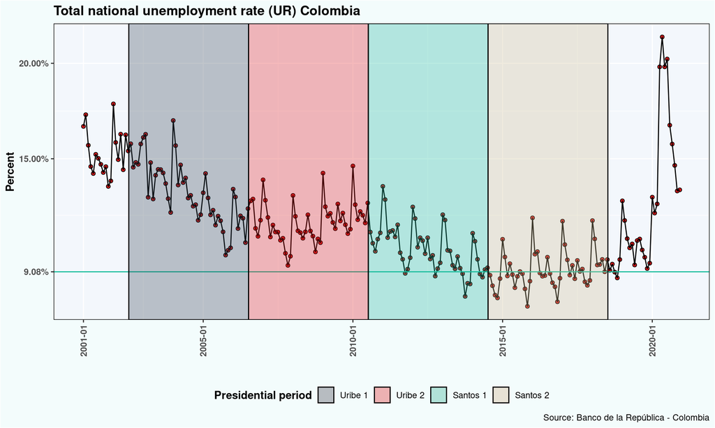

11. Point out if the hashtag on the twitter message is valid. **(3 points)**

The hashtag is not valid and is also quite misleading. If it were true the country would be bankrupt long ago.

# The goods market

This exercise is taken from:

**Oliver Blanchard (2017) Macroeconomics (7 Edition)** > Chapter 3 The Goods Market > Questions and Problems > Exercise 2

- The following equations refer to the goods market of an economy in billions of euros:

$$C_t = 480 + 0.5Y_{tD}$$
$$I_t = 110$$
$$T_t = 70$$
$$G_t = 250$$

12. Solve for the goods market equilibrium **(5 points)**
- Goods market equilibrium

$$Y_t = Z_t$$
We are assuming that the economy is closed, that is, there are no commercial relationships with the rest of the world:

$$\begin{split}
Y_t & = C_t + I_t + G_t \\
Y_t & = 480 + 0.5Y_{tD} + I_t + G_t \\
Y_t & = 480 + 0.5(Y_t - T_t) + I_t + G_t \\
0.5Y_t & = 480 - 0.5T_t + I_t + G_t \\
Y_t & = \frac{480 - 0.5T_t + I_t + G_t}{0.5} \\
Y_t & = \frac{480 - (0.5*70) + 110 + 250}{0.5} \\
Y_t & = \frac{805}{0.5} \\
Y_t & = 1610
\end{split}$$

13. Find equilibrium disposable income $(Y_{tD})$ **(5 points)**

$$\begin{split}
Y_{tD} & = Y_t - T_t \\
Y_{tD} & = 1610 - 70 \\
Y_{tD} & = 1540
\end{split}$$

14. Find equilibrium consumption $(C_t)$ **(4 points)**

$$\begin{split}
C_t = 480 + 0.5Y_{tD} \\
C_t = 480 + 0.5*1540 \\
C_t = 1250
\end{split}$$